# 3D graphics and Data Visualisation

3D scatterplot with the rgl package

Hayward Wong

### Tutorial Aims and steps:

#### 1. Understanding rgl

#### 2. Plotting 3D plots with rgl

#### 3. Setting up view point for rgl plot

#### 4. Displaying an interactive rgl plot

Today we will be using the`rgl` package to create interactive 3D Scatterplots of our data.

## 1. Introduction to `rgl`

{: #intro}

`rgl` is a 3D graphics package that produces a real-time interactive 3D plot. It allows to interactively rotate, zoom the graphics and select regions.

### Downloading `rgl`

To get 3D plots working in RStudio, the first thing you need is the `rgl` package, which you can get from [CRAN](https://cran.r-project.org/web/packages/rgl/index.html) by running the following commands in R or RStudio:

```r
install.packages("rgl")
```

## 2.Downloading data

We will use four calendar years of hyrdrological data for the Catchwater Catchment in Holderness, Yorkshire and another imaginery set of data, including daily rainfall, runoff and evaporation in this tutorial.

The data for this tutorial can be downloaded from [this repository](https://hayward-wong.github.io/3D-datavis/). Clone and download the repo as a zipfile, then unzip and set the folder as your working directory by running the code below (replacing with your actual folder path), or clicking `Session/ Set Working Directory/ Choose Directory` from the RStudio menu.

Alternatively, you can fork [the repository](https://hayward-wong.github.io/3D-datavis/) to your own GitHub account and then add it as a new RStudio project by copying the HTTPS/SSH link. For more details on how to register on GitHub, download Git, sync RStudio and Github and use version control, please check out our [Git tutorial](https://ourcodingclub.github.io/tutorials/git/).

Make a new script file through clicking `File/ New File/ R Script`, give it a title and some information, and we are all set to explore

```r
## 3D graphics in R
## Data visualisation tutorial
## YOUR NAME
## DATE
#
# Load libraries ----
library(tidyverse)  # For data manipulation
library(rgl)  # For 3D data visualisation

setwd("PATH_TO_FOLDER")  # Set working directory to the folder where you saved the data

# Read in data ----
catchwater <- read.csv("Catchment_data_1967-1970.csv")
```

We will first explore our dataset using the `str()` function, which shows what type each variable is. What is the dataset made of?

```r
str(catchwater)

# Year - Year when the data is collected
# Month - Month when the data is collected
# Time - Month and Year the data is collected
# Rain..mm.day. - mean daily rainfall for the month in mm/day
# Discharge..mm.day. - mean daily discharge for the month in mm/day
# Evap..mm.day - mean daily evaporation for the month in mm/day
```

We then can name the 3 numeric variables into x,y & z respectively.

```
#transform the 3 numeric columns into x,y & z
x <- rain <- catchwater$Rain..mm.day.
y <- disc. <- catchwater$Discharge..mm.day.
z <- evap. <- catchwater$Evap..mm.day.
```

## 3.Plotting 3D plots with `rgl`

{: #plot}

You then use the `plot3d` function from `rgl` to plot the data in a 3D scatter plot.

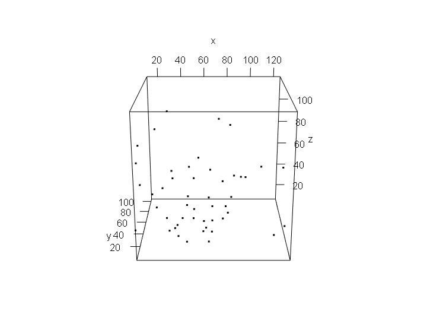

```r
plot3d(x,y,z) #Plotting x,y & z variables
```

Using the `rgl.snapshot()`function, we can save a screenshot of the output into .png format. Its often good to close the current device first before starting a new plot, this can be done with the `rgl.close()` function.

```r
rgl.snapshot("initial.png") #taking screenshot of the device

rgl.close() #closing the devcie
```